# As-a-Statistician-Time Series Analysis

### Autoregressive Processes

A $p$ th-order autoregressive process $\left\{Y_{t}\right\}$ satisfies the equation
$$Y_{t}=\phi_{1} Y_{t-1}+\phi_{2} Y_{t-2}+\cdots+\phi_{p} Y_{t-p}+e_{t}$$
The current value of the series $Y_{t}$ is a linear combination of the $p$ most recent past values of itself plus an “innovation” term $e_{t}$ that incorporates everything new in the series at time $t$ that is not explained by the past values. Thus, for every $t$, we assume that $e_{t}$ is independent of $Y_{t-1}, Y_{t-2}, Y_{t-3}, \ldots .$ Yule (1926) carried out the original work on autoregressive processes.

#### AR(1): The First-Order Autoregressive Process

Assume the series is stationary and satisfies
$$Y_{t}=\phi Y_{t-1}+e_{t}$$

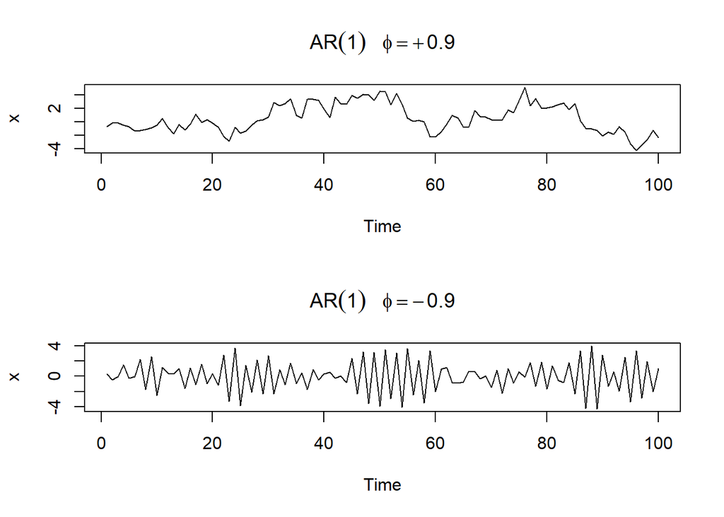

```r
### Sample Path of an AR(1) Process
par(mfrow=c(2,1))
plot(arima.sim(list(order=c(1,0,0), ar=.9), n=100), ylab="x",
main=(expression(AR(1)~~~phi==+.9)))
plot(arima.sim(list(order=c(1,0,0), ar=-.9), n=100), ylab="x",
main=(expression(AR(1)~~~phi==-.9)))
```

We first take variances of both sides above and obtain
$$\gamma_{0}=\phi^{2} \gamma_{0}+\sigma_{e}^{2}$$
Solving for $\gamma_{0}$ yields
$$\gamma_{0}=\frac{\sigma_{e}^{2}}{1-\phi^{2}}$$
$$\gamma_{k}=\phi \gamma_{k-1} \quad \text { for } k=1,2,3, \ldots$$
Setting $k=1$, we get $\gamma_{1}=\phi \gamma_{0}=\phi \sigma_{e}^{2} /\left(1-\phi^{2}\right) .$ With $k=2$, we obtain $\gamma_{2}=$ $\phi^{2} \sigma_{e}^{2} /\left(1-\phi^{2}\right)$. Now it is easy to see that in general
$$\gamma_{k}=\phi^{k} \frac{\sigma_{e}^{2}}{1-\phi^{2}}$$
and thus
$$\rho_{k}=\frac{\gamma_{k}}{\gamma_{0}}=\phi^{k} \quad \text { for } k=1,2,3, \ldots$$
Since $|\phi|<1$, the magnitude of the autocorrelation function decreases exponentially as the number of lags, $k$, increases. If $0<\phi<1$, all correlations are positive; if $-1<\phi<0$, the lag 1 autocorrelation is negative $\left(\rho_{1}=\phi\right)$ and the signs of successive autocorrelations alternate from positive to negative, with their magnitudes decreasing exponentially.

**Recursive definition of the AR(1) process**

The recursive definition is valid for all $t .$ If we use this equation with $t$ replaced by $t-1$, we get $Y_{t-1}=$ $\phi Y_{t-2}+e_{t-1} .$ Substituting this into the original expression gives
$$\begin{aligned}
Y_{t} &=\phi\left(\phi Y_{t-2}+e_{t-1}\right)+e_{t} \\
&=e_{t}+\phi e_{t-1}+\phi^{2} Y_{t-2}
\end{aligned}$$
If we repeat this substitution into the past, say $k-1$ times, we get
$$Y_{t}=e_{t}+\phi e_{t-1}+\phi^{2} e_{t-2}+\cdots+\phi^{k-1} e_{t-k+1}+\phi^{k} Y_{t-k}$$
Assuming $|\phi|<1$ and letting $k$ increase without bound, it seems reasonable (this is almost a rigorous proof) that we should obtain the infinite series representation
$$Y_{t}=e_{t}+\phi e_{t-1}+\phi^{2} e_{t-2}+\phi^{3} e_{t-3}+\cdots$$

we should note that the autocorrelation function for the AR(1) process has been derived in two different ways. The first method used the general linear process representation. The second method used the defining recursion.

#### AR(2): The Second-Order Autoregressive Process

Now consider the series satisfying
$$Y_{t}=\phi_{1} Y_{t-1}+\phi_{2} Y_{t-2}+e_{t}$$
where, as usual, we assume that $e_{t}$ is independent of $Y_{t-1}, Y_{t-2}, Y_{t-3}, \ldots .$ To discuss stationarity, we introduce the **AR characteristic polynomial**
$$\phi(x)=1-\phi_{1} x-\phi_{2} x^{2}$$
and the corresponding **AR characteristic equation**
$$1-\phi_{1} x-\phi_{2} x^{2}=0$$
We recall that a quadratic equation always has two roots (possibly complex).

In the second-order case, the roots of the quadratic characteristic equation are easily found to be
$$\frac{\phi_{1} \pm \sqrt{\phi_{1}^{2}+4 \phi_{2}}}{-2 \phi_{2}}$$
For stationarity, we require that these roots exceed 1 in absolute value. This will be true if and only if three conditions are satisfied:
$$\phi_{1}+\phi_{2}<1, \quad \phi_{2}-\phi_{1}<1, \quad \text { and } \quad\left|\phi_{2}\right|<1$$
As with the AR(1) model, we call these the stationarity conditions for the AR(2) model. This stationarity region is displayed in the following.

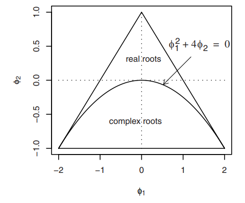

Stationarity Parameter Region for AR(2) Process

**Autocorrelation Function for the AR(2) Process**

Assuming stationarity, zero means, and that $e_{t}$ is independent of $Y_{t-k}$, we get
$$\gamma_{k}=\phi_{1} \gamma_{k-1}+\phi_{2} \gamma_{k-2} \quad \text { for } k=1,2,3, \ldots$$
or, dividing through by $\gamma_{0}$,
$$\rho_{k}=\phi_{1} \rho_{k-1}+\phi_{2} \rho_{k-2} \quad \text { for } k=1,2,3, \ldots$$
the two equations are usually called the Yule-Walker equations, especially the set of two equations obtained for $k=1$ and $2 .$ Setting $k=1$ and using $\rho_{0}=1$ and $\rho_{-1}=\rho_{1}$, we get $\rho_{1}=\phi_{1}+\phi_{2} \rho_{1}$ and so
$$\rho_{1}=\frac{\phi_{1}}{1-\phi_{2}}$$
Using the now known values for $\rho_{1}$ (and $\rho_{0}$ ), Equation $\rho_{k}=\phi_{1} \rho_{k-1}+\phi_{2} \rho_{k-2} \quad \text { for } k=1,2,3, \ldots$ can be used with $k=2$ to obtain
$$\begin{aligned}
\rho_{2} &=\phi_{1} \rho_{1}+\phi_{2} \rho_{0} \\
&=\frac{\phi_{2}\left(1-\phi_{2}\right)+\phi_{1}^{2}}{1-\phi_{2}}
\end{aligned}$$
Successive values of $\rho_{k}$ may be easily calculated numerically from the recursive relationship

**The Variance for the AR(2) Model**

Taking the variance of both sides of Equation $Y_{t}=\phi_{1} Y_{t-1}+\phi_{2} Y_{t-2}+e_{t}$ yields
$$\gamma_{0}=\left(\phi_{1}^{2}+\phi_{2}^{2}\right) \gamma_{0}+2 \phi_{1} \phi_{2} \gamma_{1}+\sigma_{e}^{2}$$
$$\begin{aligned}
\gamma_{0} &=\frac{\left(1-\phi_{2}\right) \sigma_{e}^{2}}{\left(1-\phi_{2}\right)\left(1-\phi_{1}^{2}-\phi_{2}^{2}\right)-2 \phi_{2} \phi_{1}^{2}} \\
&=\left(\frac{1-\phi_{2}}{1+\phi_{2}}\right) \frac{\sigma_{e}^{2}}{\left(1-\phi_{2}\right)^{2}-\phi_{1}^{2}}
\end{aligned}$$

### The Mixed Autoregressive Moving Average Model

If we assume that the series is partly autoregressive and partly moving average, we obtain a quite general time series model. In general, if
$$\begin{array}{r}
Y_{t}=\phi_{1} Y_{t-1}+\phi_{2} Y_{t-2}+\cdots+\phi_{p} Y_{t-p}+e_{t}-\theta_{1} e_{t-1}-\theta_{2} e_{t-2} \\
-\cdots-\theta_{q} e_{t-q}
\end{array}$$
we say that $\left\{Y_{t}\right\}$ is a mixed autoregressive moving average process of orders $p$ and $q$ respectively; we abbreviate the name to $\operatorname{ARMA}(p, q)$.

#### ARMA(1,1) Model

The defining equation can be written
$$Y_{t}=\phi Y_{t-1}+e_{t}-\theta e_{t-1}$$
To derive Yule-Walker type equations, we first note that
$$\begin{aligned}
E\left(e_{t} Y_{t}\right) &=E\left[e_{t}\left(\phi Y_{t-1}+e_{t}-\theta e_{t-1}\right)\right] \\
&=\sigma_{e}^{2}
\end{aligned}$$
$$\begin{aligned}
E\left(e_{t-1} Y_{t}\right) &=E\left[e_{t-1}\left(\phi Y_{t-1}+e_{t}-\theta e_{t-1}\right)\right] \\
&=\phi \sigma_{e}^{2}-\theta \sigma_{e}^{2} \\
&=(\phi-\theta) \sigma_{e}^{2}
\end{aligned}$$
If we multiply Equation ($Y_{t}=\phi Y_{t-1}+e_{t}-\theta e_{t-1}$) by $Y_{t-k}$ and take expectations, we have
$$\left.\begin{array}{l}
\gamma_{0}=\phi \gamma_{1}+[1-\theta(\phi-\theta)] \sigma_{e}^{2} \\
\gamma_{1}=\phi \gamma_{0}-\theta \sigma_{e}^{2} \\
\gamma_{k}=\phi \gamma_{k-1} \quad \text { for } k \geq 2
\end{array}\right\}$$
Solving the first two equations yields
$$\gamma_{0}=\frac{\left(1-2 \phi \theta+\theta^{2}\right)}{1-\phi^{2}} \sigma_{e}^{2}$$
and solving the simple recursion gives
$$\rho_{k}=\frac{(1-\theta \phi)(\phi-\theta)}{1-2 \theta \phi+\theta^{2}} \phi^{k-1} \quad \text { for } k \geq 1$$

### Invertibility

We have seen that for the MA(1) process we get exactly the same autocorrelation function if $\theta$ is replaced by $1 / \theta$.

For example the 2 models $Y_{t}=e_{t}-\theta e_{t-1}$ and $Y_{t}=e_{t}-\frac{1}{\theta} e_{t-1}$ have equal autocorrelation coefficient.

### Fit the AR model in R

```r
library(tseries)
#Loading the Data Set
data("AirPassengers")

#This tells you that the data series is in a time series format
is.ts(AirPassengers)
```

```
## [1] TRUE
```

```r
#Starting index, end index
start(AirPassengers)
```

```
## [1] 1949    1
```

```r
end(AirPassengers)
```

```
## [1] 1960   12
```

```r
time(AirPassengers)
```

```
##           Jan      Feb      Mar      Apr      May      Jun      Jul      Aug
## 1949 1949.000 1949.083 1949.167 1949.250 1949.333 1949.417 1949.500 1949.583
## 1950 1950.000 1950.083 1950.167 1950.250 1950.333 1950.417 1950.500 1950.583
## 1951 1951.000 1951.083 1951.167 1951.250 1951.333 1951.417 1951.500 1951.583
## 1952 1952.000 1952.083 1952.167 1952.250 1952.333 1952.417 1952.500 1952.583
## 1953 1953.000 1953.083 1953.167 1953.250 1953.333 1953.417 1953.500 1953.583
## 1954 1954.000 1954.083 1954.167 1954.250 1954.333 1954.417 1954.500 1954.583
## 1955 1955.000 1955.083 1955.167 1955.250 1955.333 1955.417 1955.500 1955.583
## 1956 1956.000 1956.083 1956.167 1956.250 1956.333 1956.417 1956.500 1956.583
## 1957 1957.000 1957.083 1957.167 1957.250 1957.333 1957.417 1957.500 1957.583
## 1958 1958.000 1958.083 1958.167 1958.250 1958.333 1958.417 1958.500 1958.583
## 1959 1959.000 1959.083 1959.167 1959.250 1959.333 1959.417 1959.500 1959.583
## 1960 1960.000 1960.083 1960.167 1960.250 1960.333 1960.417 1960.500 1960.583
##           Sep      Oct      Nov      Dec
## 1949 1949.667 1949.750 1949.833 1949.917
## 1950 1950.667 1950.750 1950.833 1950.917
## 1951 1951.667 1951.750 1951.833 1951.917
## 1952 1952.667 1952.750 1952.833 1952.917
## 1953 1953.667 1953.750 1953.833 1953.917
## 1954 1954.667 1954.750 1954.833 1954.917
## 1955 1955.667 1955.750 1955.833 1955.917
## 1956 1956.667 1956.750 1956.833 1956.917
## 1957 1957.667 1957.750 1957.833 1957.917
## 1958 1958.667 1958.750 1958.833 1958.917
## 1959 1959.667 1959.750 1959.833 1959.917
## 1960 1960.667 1960.750 1960.833 1960.917
```

```r
#This will print the cycle across years.
frequency(AirPassengers)
```

```
## [1] 12
```

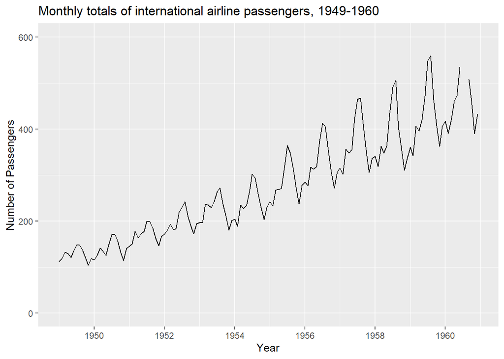

```r
## plot the time series
library(ggplot2)
library(fpp)
###  the autoplot() command frequently. It automatically produces an appropriate plot of whatever you pass to it in the first argument. In this case, it recognises melsyd[,"Economy.Class"] as a time series and produces a time plot.
reg=lm(AirPassengers~time(AirPassengers))

autoplot(AirPassengers) +
  ylim(0, 600) +
  ggtitle("Monthly totals of international airline passengers, 1949-1960") +
  xlab("Year") +
  ylab("Number of Passengers")
```

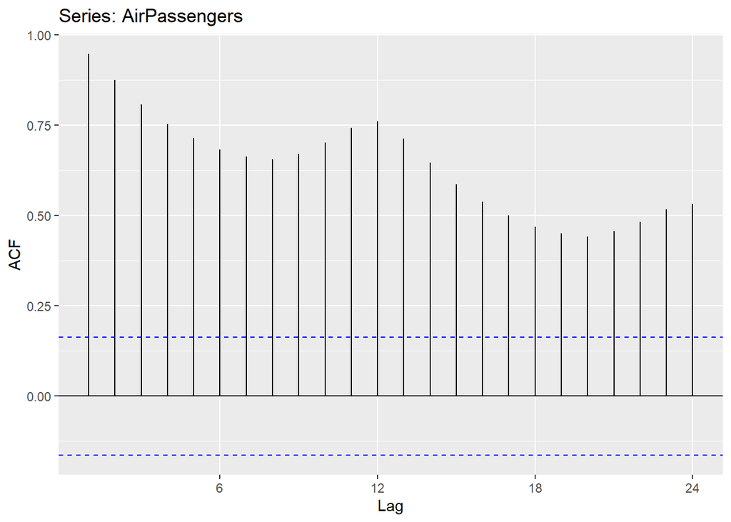

```r
## ACF help us determine what type of series we have, whether it is a White noise, Random walk, Auto regressive or Moving average.
ggAcf(AirPassengers)
```

```r
## Fit the AR model to AirPassengers
## Note for reference that an AR model is an ARIMA(1, 0, 0) model.
AR <- arima(AirPassengers, order = c(1,0,0))
print(AR)
```

```
##
## Call:
## arima(x = AirPassengers, order = c(1, 0, 0))
##
## Coefficients:
##          ar1  intercept
##       0.9646   278.4649
## s.e.  0.0214    67.1141
##
## sigma^2 estimated as 1119:  log likelihood = -711.09,  aic = 1428.18
```

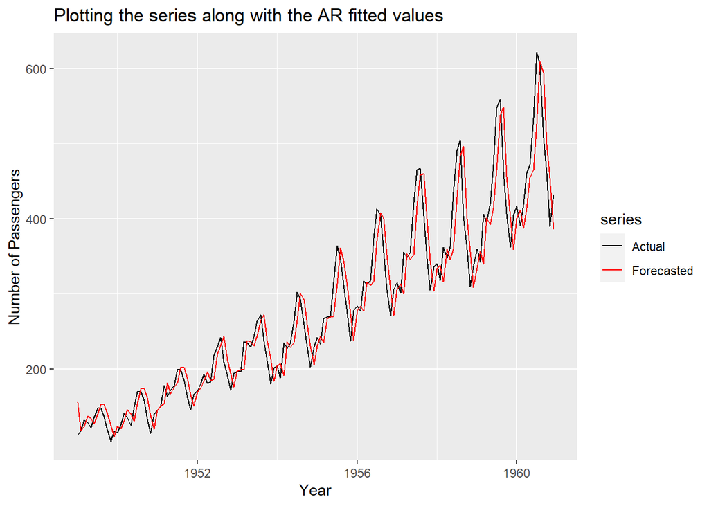

```r
#plotting the series along with the fitted values
library(zoo)
library(tseries)
library(ggplot2)
library(ggfortify)
AR_fit <- AirPassengers - residuals(AR)
autoplot(ts.union(AirPassengers, AR_fit), facets = FALSE) +
 scale_color_manual(labels = c("Actual", "Forecasted"),
                    values=c("black", "red")) +
  ggtitle("Plotting the series along with the AR fitted values") +
  xlab("Year") +
  ylab("Number of Passengers")
```

```r
#Using predict() to make a 1-step forecast
predict_AR <- predict(AR)

#Obtaining the 1-step forecast using $pred[1]
predict_AR$pred[1]
```

```
## [1] 426.5698
```

```r
#ALternatively Using predict to make 1-step through 10-step forecasts
predict(AR, n.ahead = 10)
```

```
## $pred
##           Jan      Feb      Mar      Apr      May      Jun      Jul      Aug
## 1961 426.5698 421.3316 416.2787 411.4045 406.7027 402.1672 397.7921 393.5717
##           Sep      Oct
## 1961 389.5006 385.5735
##
## $se
##           Jan      Feb      Mar      Apr      May      Jun      Jul      Aug
## 1961 33.44577 46.47055 55.92922 63.47710 69.77093 75.15550 79.84042 83.96535
##           Sep      Oct
## 1961 87.62943 90.90636
```

### Fit the MA model in R

```r
#Fitting the MA model to AirPassengers
MA <- arima(AirPassengers, order = c(0,0,1))
print(MA)
```

```
##
## Call:
## arima(x = AirPassengers, order = c(0, 0, 1))
##
## Coefficients:
##          ma1  intercept
##       0.9642   280.6464
## s.e.  0.0214    10.5788
##
## sigma^2 estimated as 4205:  log likelihood = -806.43,  aic = 1618.86
```

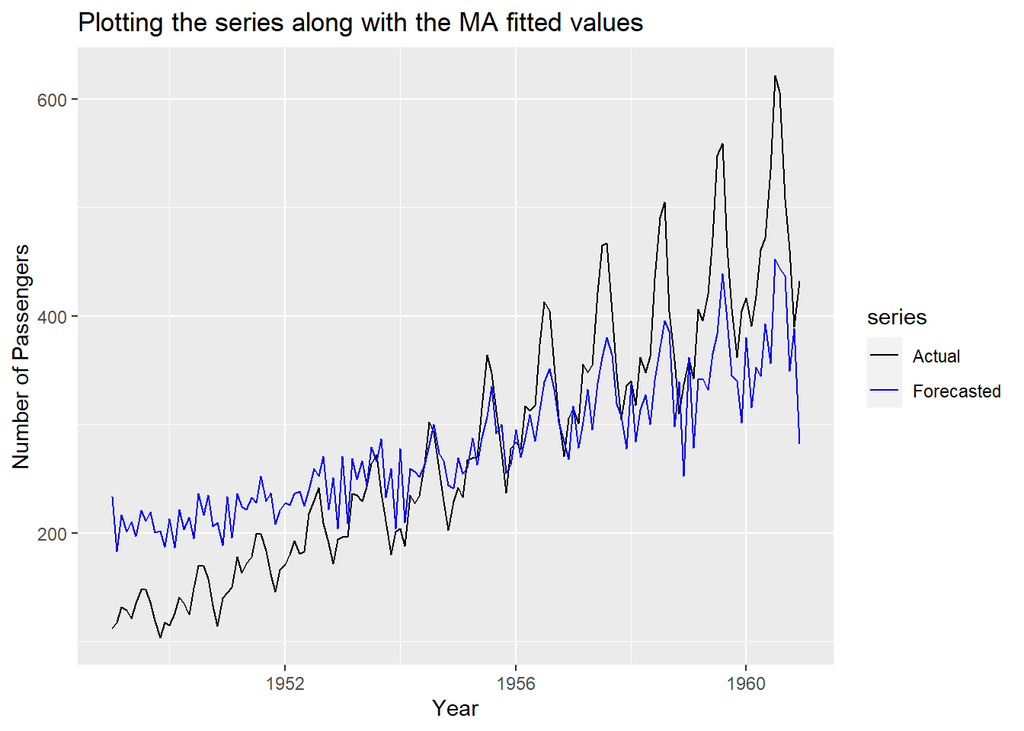

```r
autoplot(ts.union(AirPassengers, AirPassengers - resid(MA)), facets = FALSE) +
 scale_color_manual(labels = c("Actual", "Forecasted"),
                    values=c("black", "blue")) +
  ggtitle("Plotting the series along with the MA fitted values") +
  xlab("Year") +
  ylab("Number of Passengers")
```

```r
#Alternately Making a 1-step through 10-step forecast based on MA
predict(MA,n.ahead=10)
```

```
## $pred
##           Jan      Feb      Mar      Apr      May      Jun      Jul      Aug
## 1961 425.1049 280.6464 280.6464 280.6464 280.6464 280.6464 280.6464 280.6464
##           Sep      Oct
## 1961 280.6464 280.6464
##
## $se
##           Jan      Feb      Mar      Apr      May      Jun      Jul      Aug
## 1961 64.84895 90.08403 90.08403 90.08403 90.08403 90.08403 90.08403 90.08403
##           Sep      Oct
## 1961 90.08403 90.08403
```

```r
# Find correlation between AR_fit and MA_fit
MA_fit <- AirPassengers - resid(MA)
cor(AR_fit, MA_fit)
```

```
## [1] 0.954995
```

```r
# Find AIC of AR
AIC(AR)
```

```
## [1] 1428.179
```

```r
AIC(MA)
```

```
## [1] 1618.863
```

```r
BIC(AR)
```

```
## [1] 1437.089
```

```r
BIC(MA)
```

```
## [1] 1627.772
```

Once we have got the models ready we must answer the important question: Should we choose AR or MA process? Goodness of fit such as an Information criteria is an method to help us make the decision. Specifically Akaike information criterion (AIC) and Bayesian information criterion (BIC) are used for Time series Models. Information Criteria is a more advanced concept but for either measure a lower value indicates a relatively better fitting model.

## ARIMA Models

> MODELS FOR NONSTATIONARY TIME SERIES

### Stationarity Through Differencing

Consider again the AR(1) model
$$Y_{t}=\phi Y_{t-1}+e_{t}$$
We have seen that assuming $e_{t}$ is a true “innovation” (that is, $e_{t}$ is uncorrelated with $\left.Y_{t-1}, Y_{t-2}, \ldots\right)$, we must have $|\phi|<1$. What can we say about solutions to above Equation if $|\phi| \geq 1$

When $\phi=1$. If $\phi=1$, the AR(1) model equation is
$$Y_{t}=Y_{t}+e_{t}$$
This is the relationship satisfied by the random walk process. Alternatively, we can rewrite this as
$$\nabla Y_{t}=e_{t}$$

$$Y_{t}=M_{t}+e_{t}, \quad \text { where } \quad M_{t}=M_{t-1}+W_{t}$$
with $\left\{e_{t}\right\}$ and $\left\{\varepsilon_{t}\right\}$ independent white noise time series. Here the stochastic trend $M_{t}$ is such that its “rate of change,” $\nabla M_{t}$, is changing slowly over time. Then
$$\nabla Y_{t}=\nabla M_{t}+\nabla e_{t}=W_{t}+\nabla e_{t}$$

### ARIMA: Integrated autoregressive moving average model

A time series $\left\{Y_{t}\right\}$ is said to follow an integrated autoregressive moving average model if the $d$ th difference $W_{t}=\nabla^{d} Y_{t}$ is a stationary ARMA process. If $\left\{W_{t}\right\}$ follows an ARMA $(p, q)$ model, we say that $\left\{Y_{t}\right\}$ is an ARIMA $(p, d, q)$ process. Fortunately, for practical purposes, we can usually take $d=1$ or at most 2 . Consider then an $\operatorname{ARIMA}(p, 1, q)$ process. With $W_{t}=Y_{t}-Y_{t-1}$, we have
$$\begin{array}{r}
W_{t}=\phi_{1} W_{t-1}+\phi_{2} W_{t-2}+\cdots+\phi_{p} W_{t-p}+e_{t}-\theta_{1} e_{t-1}-\theta_{2} e_{t-2} \\
-\cdots-\theta_{q} e_{t-q}
\end{array}$$
or, in terms of the observed series,
$$\begin{array}{c}
Y_{t}-Y_{t-1}=\phi_{1}\left(Y_{t-1}-Y_{t-2}\right)+\phi_{2}\left(Y_{t-2}-Y_{t-3}\right)+\cdots+\phi_{p}\left(Y_{t-p}-Y_{t-p-1}\right) \\
+e_{t}-\theta_{1} e_{t-1}-\theta_{2} e_{t-2}-\cdots-\theta_{q} e_{t-q}
\end{array}$$
which we may rewrite as
$$\begin{array}{l}
Y_{t}=\left(1+\phi_{1}\right) Y_{t-1}+\left(\phi_{2}-\phi_{1}\right) Y_{t-2}+\left(\phi_{3}-\phi_{2}\right) Y_{t-3}+\cdots \\
\quad+\left(\phi_{p}-\phi_{p-1}\right) Y_{t-p}-\phi_{p} Y_{t-p-1}+e_{t}-\theta_{1} e_{t-1}-\theta_{2} e_{t-2}-\cdots-\theta_{q} e_{t-q}
\end{array}$$
We call this the **difference equation form** of the model. Notice that it appears to be an ARMA $(p+1, q)$ process. However, the characteristic polynomial satisfies
$$\begin{array}{c}
1-\left(1+\phi_{1}\right) x-\left(\phi_{2}-\phi_{1}\right) x^{2}-\left(\phi_{3}-\phi_{2}\right) x^{3}-\cdots-\left(\phi_{p}-\phi_{p-1}\right) x^{p}+\phi_{p} x^{p+1} \\
=\left(1-\phi_{1} x-\phi_{2} x^{2}-\cdots-\phi_{p} x^{p}\right)(1-x)
\end{array}$$
which can be easily checked. This factorization clearly shows the root at $x = 1$, which implies nonstationarity

For convenience, we take $Y_{t}=0$ for $t<-m$. The difference equation $Y_{t}-Y_{t-1}=W_{t}$ can be solved by summing both sides from $t=-m$ to $t=$ $t$ to get the representation
$$Y_{t}=\sum_{j=-m}^{t} W_{j}$$
for the $\operatorname{ARIMA}(p, 1, q)$ process. The ARIMA( $p, 2, q)$ process can be dealt with similarly by summing twice to get the representations
$$\begin{aligned}
Y_{t} &=\sum_{j=-m}^{t} \sum_{i=-m}^{j} W_{i} \\
&=\sum_{j=0}^{t+m}(j+1) W_{t-j}
\end{aligned}$$

### IMA(1,1) Model

The simple IMA(1,1) model satisfactorily represents numerous time series, especially those arising in economics and business. In difference equation form, the model is
$$Y_{t}=Y_{t-1}+e_{t}-\theta e_{t-1}$$
To write $Y_{t}$ explicitly as a function of present and past noise values, we use Equation $Y_{t}=\sum_{j=-m}^{t} W_{j}$ and the fact that $W_{t}=e_{t}-\theta e_{t-1}$ in this case. After a little rearrangement, we can write
$$Y_{t}=e_{t}+(1-\theta) e_{t-1}+(1-\theta) e_{t-2}+\cdots+(1-\theta) e_{-m}-\theta e_{-m-1}$$
Notice that in contrast to our stationary ARMA models, the weights on the white noise terms do not die out as we go into the past. Since we are assuming that $-m<1$ and $0<t$, we may usefully think of $Y_{t}$ as mostly an equally weighted accumulation of a large number of white noise values.

We can easily derive variances and correlations. We have
$$\operatorname{Var}\left(Y_{t}\right)=\left[1+\theta^{2}+(1-\theta)^{2}(t+m)\right] \sigma_{e}^{2}$$
and
$$\begin{aligned}
\operatorname{Corr}\left(Y_{t}, Y_{t-k}\right) &=\frac{1-\theta+\theta^{2}+(1-\theta)^{2}(t+m-k)}{\left[\operatorname{Var}\left(Y_{t}\right) \operatorname{Var}\left(Y_{t-k}\right)\right]^{1 / 2}} \\
& \approx \sqrt{\frac{t+m-k}{t+m}} \\
& \approx 1 \quad \text { for large } m \text { and moderate } k
\end{aligned}$$
We see that as $t$ increases, $\operatorname{Var}\left(Y_{t}\right)$ increases and could be quite large. Also, the correlation between $Y_{t}$ and $Y_{t-k}$ will be strongly positive for many lags $k=1,2, \ldots$.

### ARI(1,1) Model

The ARI(1,1) process will satisfy
$$Y_{t}-Y_{t-1}=\phi\left(Y_{t-1}-Y_{t-2}\right)+e_{t}$$
or
$$Y_{t}=(1+\phi) Y_{t-1}-\phi Y_{t-2}+e_{t}$$
where $|\phi|<1\rangle$

## Time series graphics

### Time plots

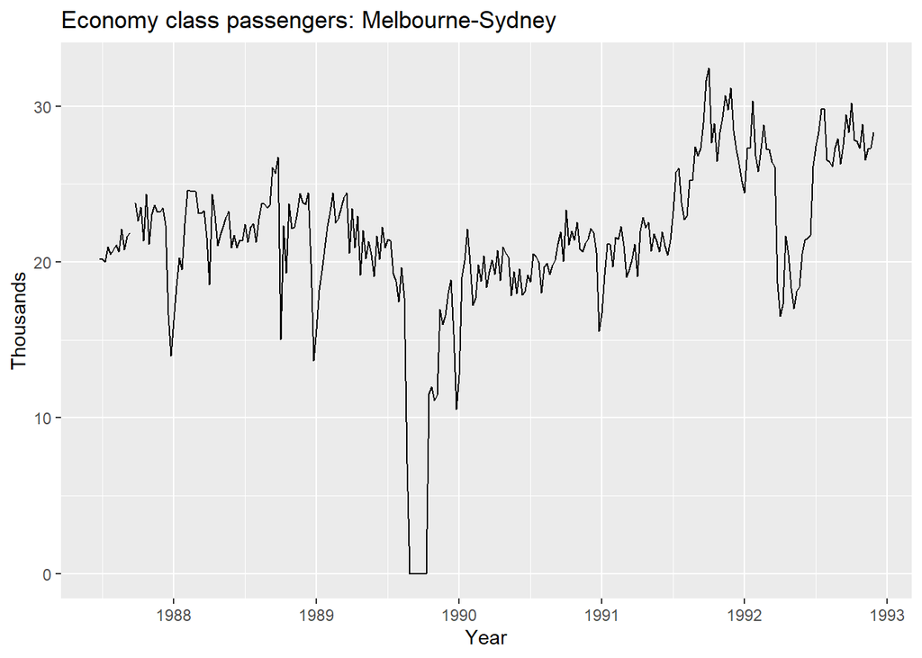

```r
require(fpp)
library(ggplot2)
data(melsyd)

###  the autoplot() command frequently. It automatically produces an appropriate plot of whatever you pass to it in the first argument. In this case, it recognises melsyd[,"Economy.Class"] as a time series and produces a time plot.
autoplot(melsyd[,"Economy.Class"]) +
  ggtitle("Economy class passengers: Melbourne-Sydney") +
  xlab("Year") +
  ylab("Thousands")
```

**Time series patterns**

In describing these time series, we have used words such as “trend” and “seasonal” which need to be defined more carefully.

### Seasonal plots

```r
require(fpp)
data(a10)
str(a10)
```

```
##  Time-Series [1:204] from 1992 to 2008: 3.53 3.18 3.25 3.61 3.57 ...
```

```r
head(a10)
```

```
##           Jul      Aug      Sep      Oct      Nov      Dec
## 1991 3.526591 3.180891 3.252221 3.611003 3.565869 4.306371
```

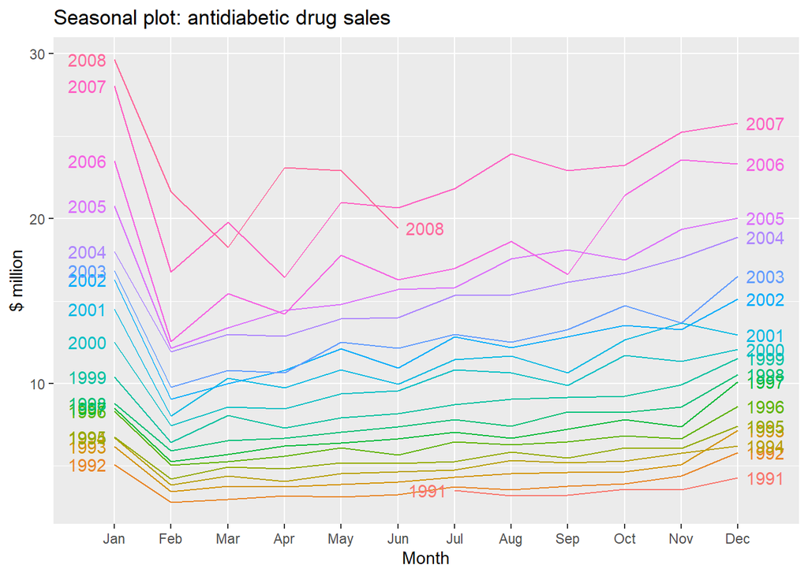

```r
ggseasonplot(a10, year.labels=TRUE, year.labels.left=TRUE) +
  ylab("$ million") +
  ggtitle("Seasonal plot: antidiabetic drug sales")
```

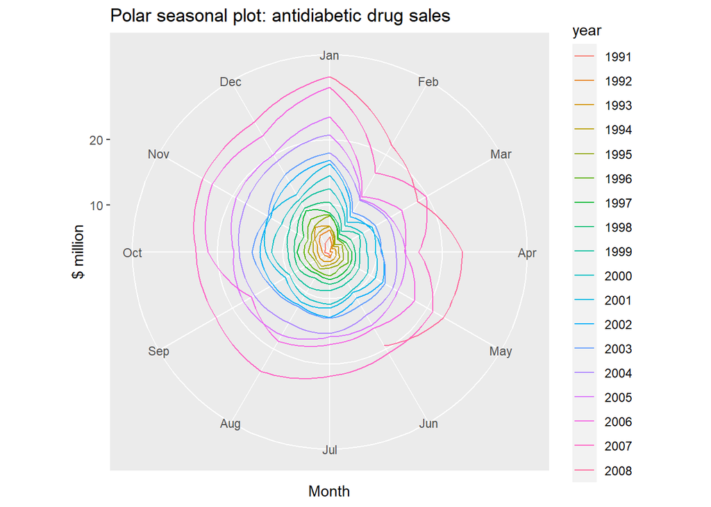

```r
### A useful variation on the seasonal plot uses polar coordinates. Setting polar=TRUE makes the time series axis circular rather than horizontal, as shown below.
ggseasonplot(a10, polar=TRUE) +
  ylab("$ million") +
  ggtitle("Polar seasonal plot: antidiabetic drug sales")
```

**Seasonal subseries plots**

An alternative plot that emphasises the seasonal patterns is where the data for each season are collected together in separate mini time plots.

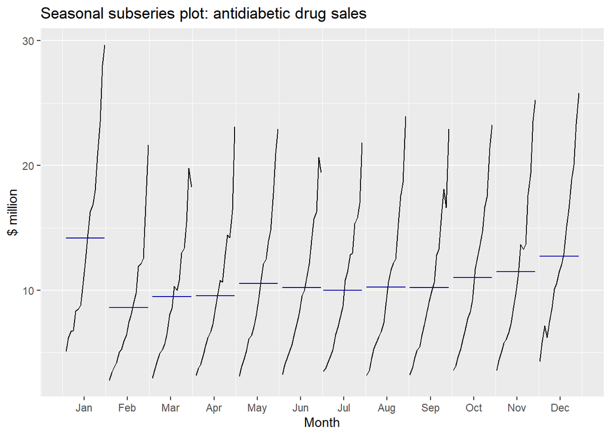

```r
ggsubseriesplot(a10) +
  ylab("$ million") +
  ggtitle("Seasonal subseries plot: antidiabetic drug sales")
```

### Scatterplots matrices

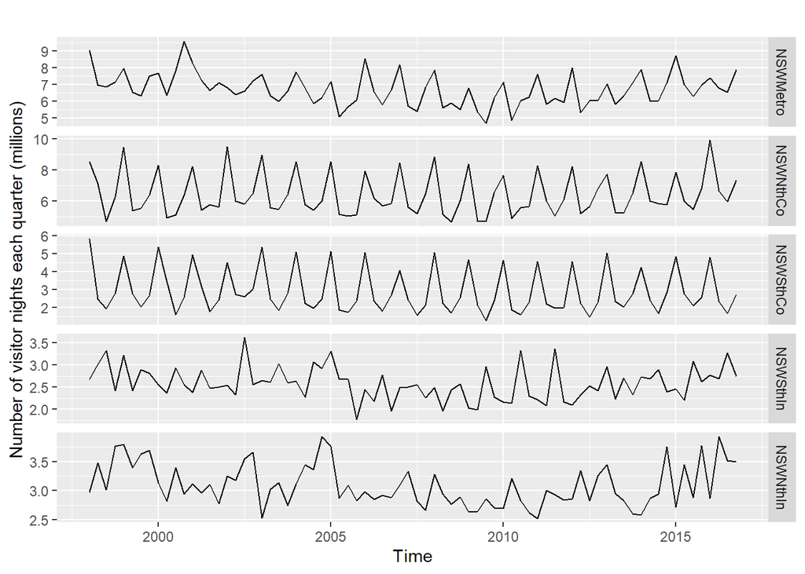

```r
library(fpp2)
data(visnights)
autoplot(visnights[,1:5], facets=TRUE) +
  ylab("Number of visitor nights each quarter (millions)")
```

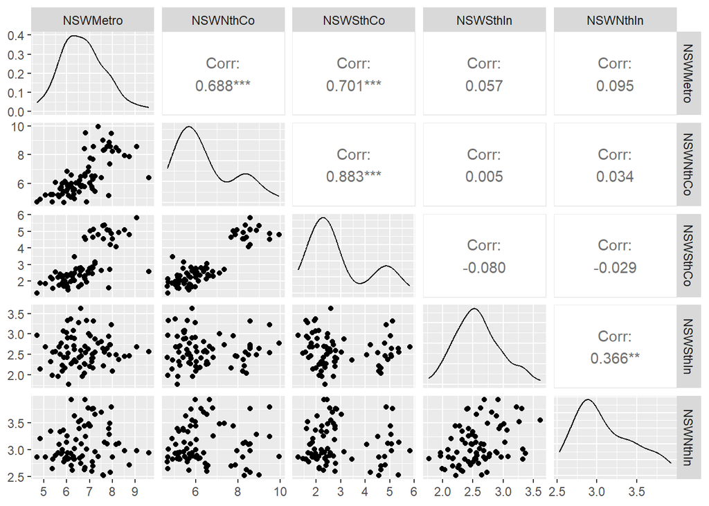

```r
## To see the relationships between these five time series, we can plot each time series against the others. These plots can be arranged in a scatterplot matrix
GGally::ggpairs(as.data.frame(visnights[,1:5]))
```

### Lag plots

The horizontal axis shows lagged values of the time series. Each graph shows $y_{t}$ plotted against $y_{t-k}$ for different values of $k$.

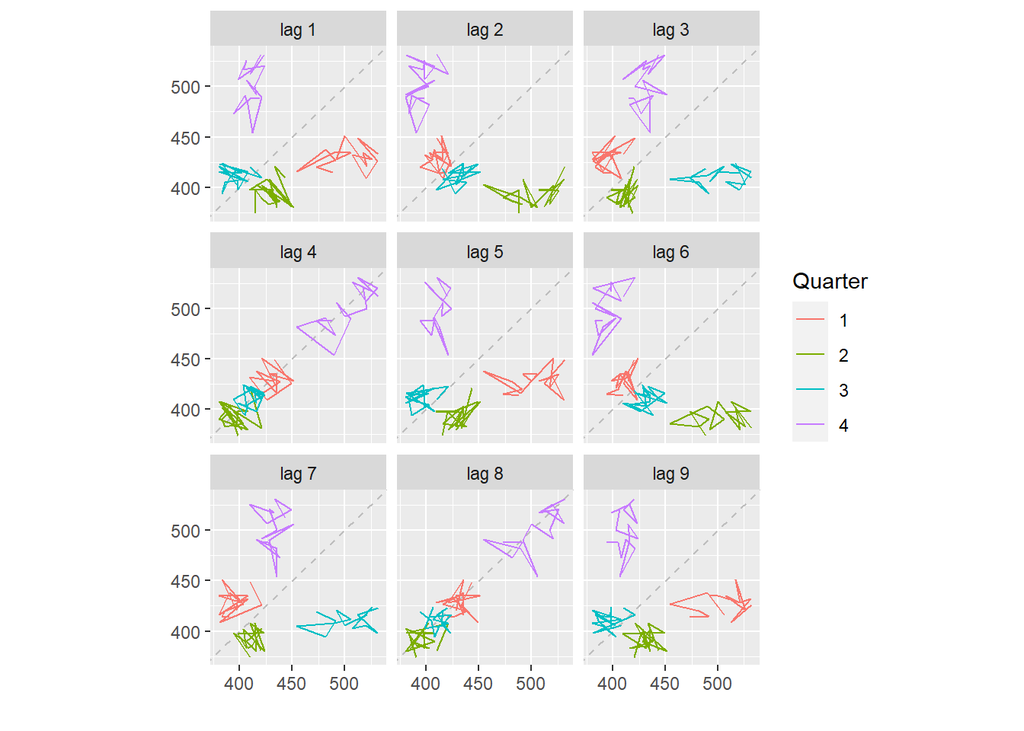

```r
## Lagged scatterplots for quarterly beer production.
library(fpp)
data(ausbeer)
## The window() function used here is very useful when extracting a portion of a time series.
beer2 <- window(ausbeer, start=1992)
gglagplot(beer2)
```

### Autocorrelation

Just as correlation measures the extent of a linear relationship between two variables, autocorrelation measures the linear relationship between lagged values of a time series.

$r_{1}$ measures the relationship between $y_{t}$ and $y_{t-1}, r_{2}$ measures the relationship between $y_{t}$ and $y_{t-2}$, and so on. The value of $r_{k}$ can be written as
$$r_{k}=\frac{\sum_{t=k+1}^{T}\left(y_{t}-\bar{y}\right)\left(y_{t-k}-\bar{y}\right)}{\sum_{t=1}^{T}\left(y_{t}-\bar{y}\right)^{2}}$$
where $T$ is the length of the time series.

The autocorrelation coefficients are plotted to show the autocorrelation function or ACF. The plot is also known as a correlogram.

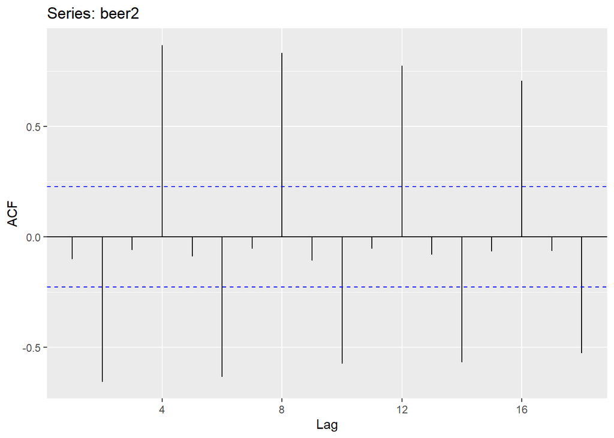

```r
ggAcf(beer2)
```

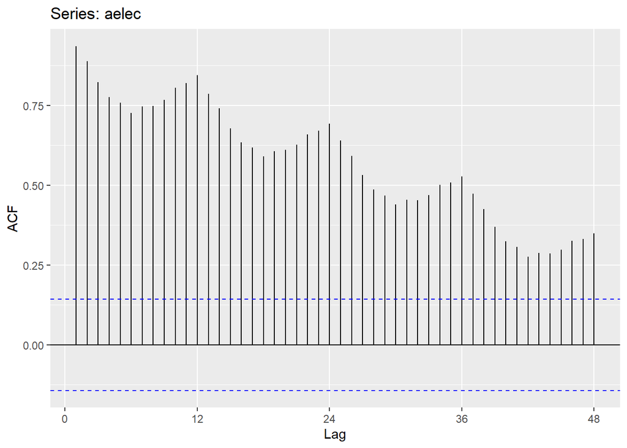

```r
data(elec)
aelec <- window(elec, start=1980)
ggAcf(aelec, lag=48)
```

### White noise

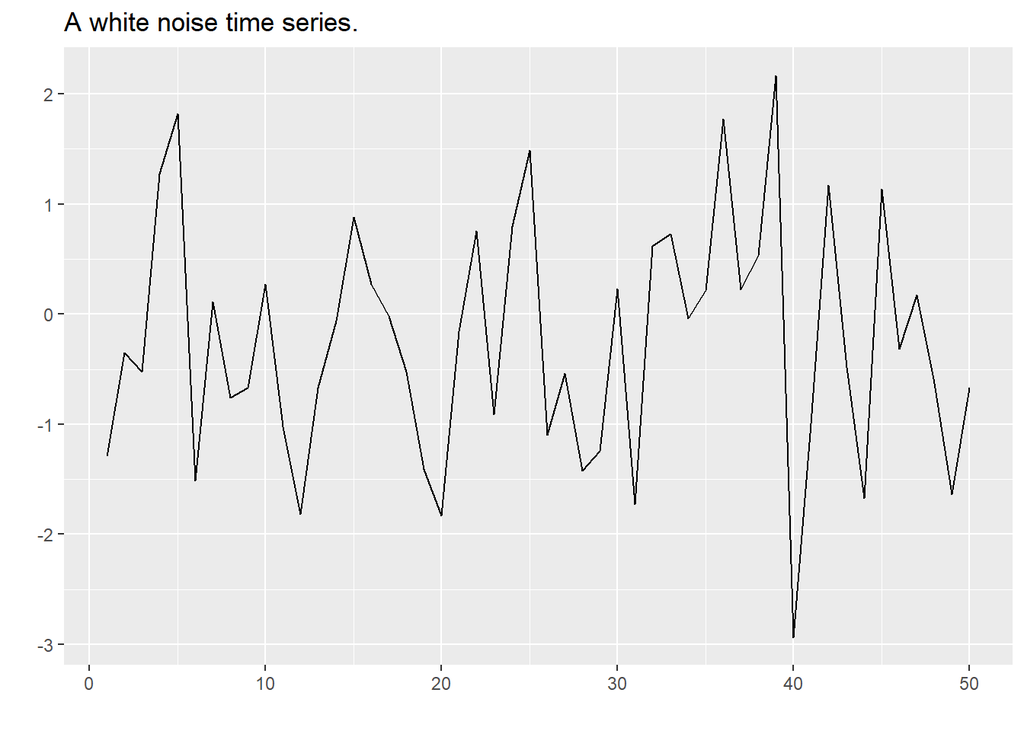

```r
set.seed(30)
y <- ts(rnorm(50))
autoplot(y) + ggtitle("A white noise time series.")
```

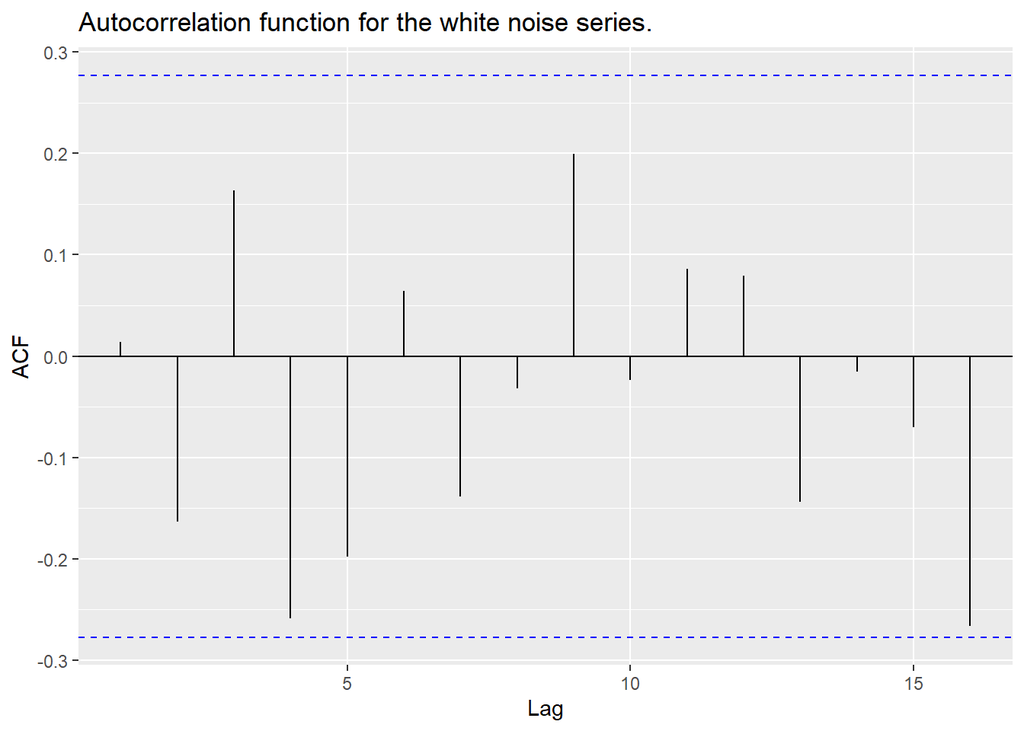

```r
ggAcf(y)+ ggtitle("Autocorrelation function for the white noise series.")
```